# Project Explore and Summarize Data

# Logistic Regression

Based in the decorrelated borrower related variables a step-wise logistic regression is performed.

The final logistic model is significantly better then randomly selecting with an accuracy of 73%.

```
## Confusion Matrix and Statistics
##
##           Reference
## Prediction    0    1
##          0 7880 2740
##          1  502  740
##
##                Accuracy : 0.7267
##                  95% CI : (0.7186, 0.7347)
##     No Information Rate : 0.7066
##     P-Value [Acc > NIR] : 7.137e-07
##
##                   Kappa : 0.1881
##  Mcnemar's Test P-Value : < 2.2e-16
##
##             Sensitivity : 0.9401
##             Specificity : 0.2126
##          Pos Pred Value : 0.7420
##          Neg Pred Value : 0.5958
##              Prevalence : 0.7066
##          Detection Rate : 0.6643
##    Detection Prevalence : 0.8953
##       Balanced Accuracy : 0.5764
##
##        'Positive' Class : 0
##
```

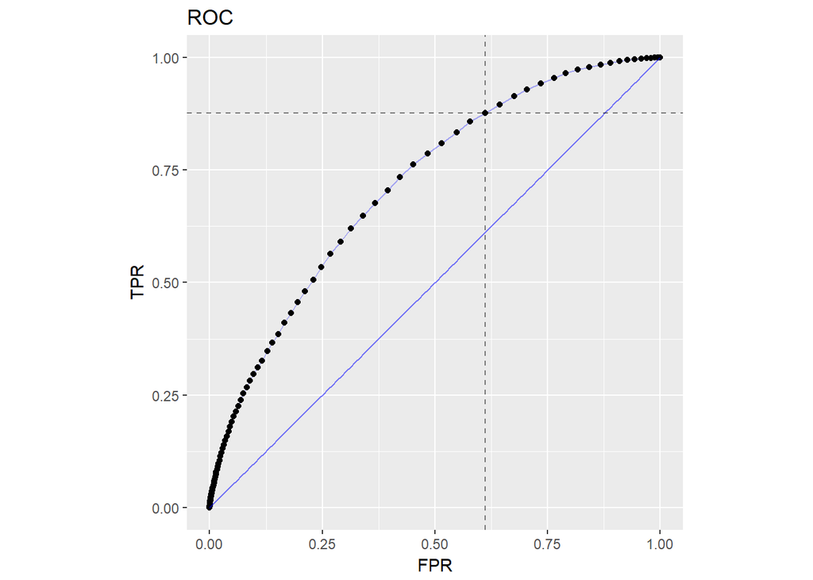

The most important variable indicating high risk according to the model is the Credit score followed by the stated income and the original amount of the loan. The higher the score, the lesser the risk, the higher the income, the lesser the risk and the higher the loan amount, the higher the risk, that the borrower is not able to repay the loan.

```
##                 LoanOriginalAmount               InquiriesLast6Months
##                         0.35060907                         0.24283666
##        OpenRevolvingMonthlyPayment            TradesOpenedLast6Months
##                         0.21087318                         0.15536906
##        ProsperPrincipalOutstanding             InquiriesBefore6Months
##                         0.15152173                         0.12909984
##   TotalClosedCreditLinesPast7years            IsBorrowerHomeownerTrue
##                         0.11336379                         0.10253438
##                    BorrowerStateFL                    BorrowerStateGA
##                         0.05052102                         0.04650109
##           EmploymentStatusDuration    `EmploymentStatusSelf-employed`
##                         0.03841628                         0.03431489
##                    BorrowerStateIL                    OccupationOther
##                         0.03329787                         0.03327338
##                  DebtToIncomeRatio                    BorrowerStateCA
##                         0.02638184                        -0.03658352
##             OccupationProfessional TradesNeverDelinquent..percentage.
##                        -0.04896917                        -0.06299216
##              OpenRevolvingAccounts                BankcardUtilization
##                        -0.06589314                        -0.08799808
##               IncomeVerifiableTRUE        `EmploymentStatusFull-time`
##                        -0.10498534                        -0.13453779
##            FirstRecordedCreditLine            AvailableBankcardCredit
##                        -0.13753600                        -0.18768692
##                        TotalTrades                  TotalProsperLoans
##                        -0.20362274                        -0.25760392
##                StatedMonthlyIncome              CreditScoreRangeLower
##                        -0.38355391                        -0.52035078
##                        (Intercept)
##                        -1.01504935
```

Compared to the Prosper Rating the predicted default probability increases with lower rating grades and the median predicted probabilities for defaulted loans are higher than the median predicted probabilities for completed loans.

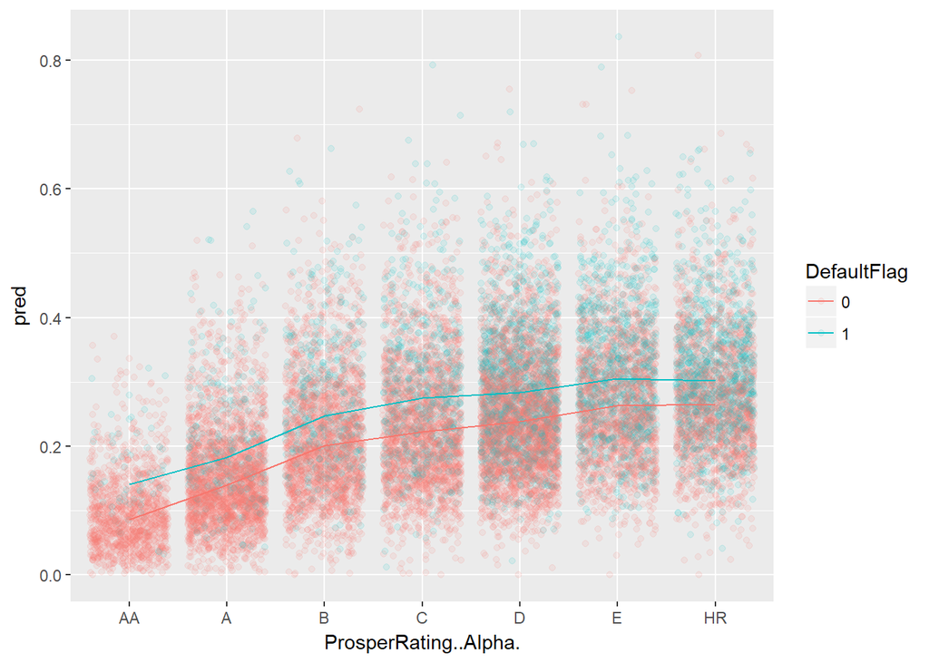

# Final Plots and Summary

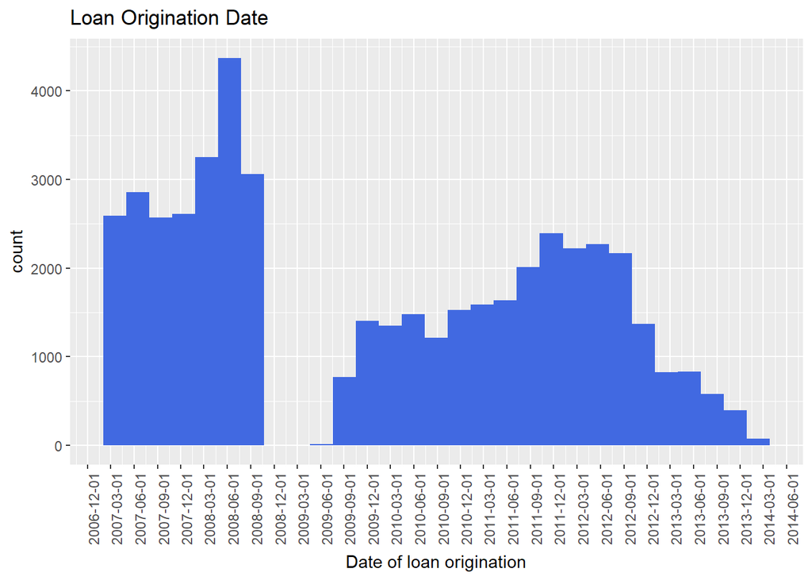

The data set contains some variables, that strongly correlate. An example is the correlation between the variables `OpenRevolvingMonthlyPayment` and `RevolvingCreditBalance`.

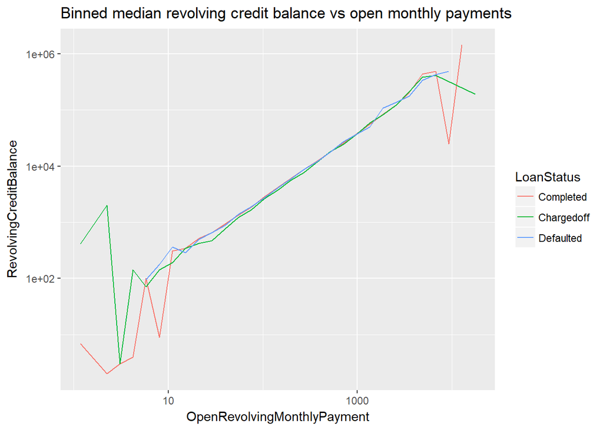

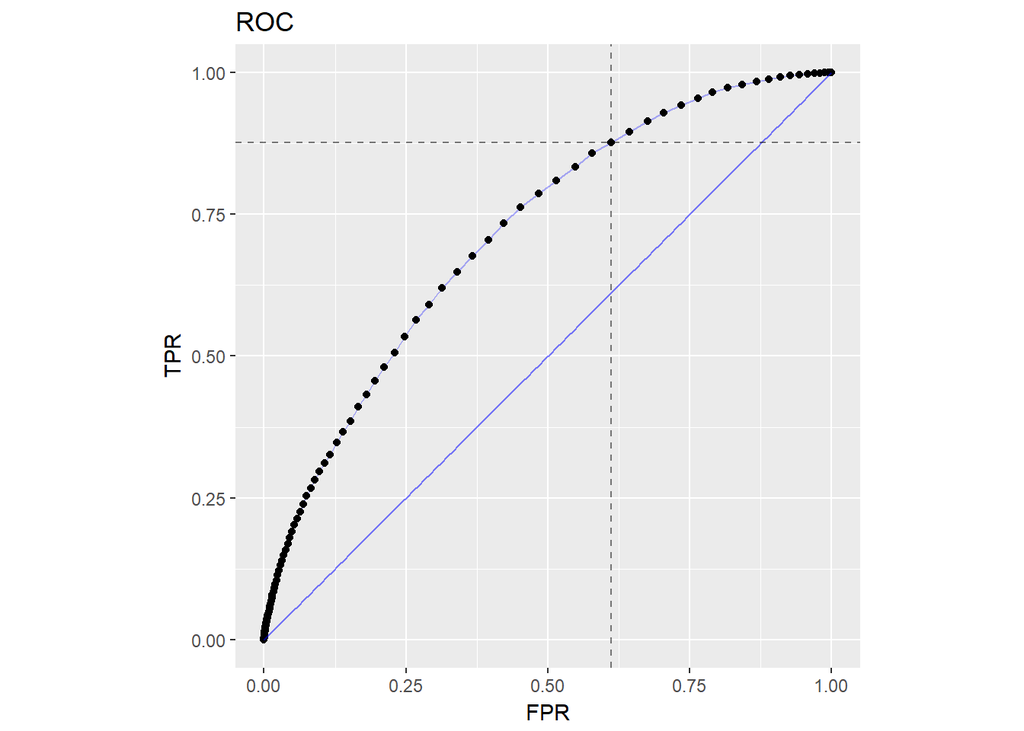

# Reflection

The data set contains data about loans originated on the peer-to-peer landing platform Prosper. The observed default rates in the data set are quite high. Prosper provides ratings for each borrower to indicate the chance that the borrower will repay the complete loan. In this analyses is shown, that it is possible to fit a simple logistic model to data to predict defaults of loans. Although the model does perform only fairly it can give additional hints on the risk of each loan in conjunction with Prospers own rating.

To improve the model one could also try to use more sophisticated models like boosted decision trees, neural nets or support vector machines, since simple logistic models to not include cross-effects between variables which these methods can include.